# final_project

Julien Korner

2025-12-10

```r
library(tidyverse)
library(patchwork)
library(randomForest)
```

```r
library(class)
library(rpart)
library(rpart.plot)
library(caret)
```

# Data

```r
HNP <- read_csv("https://raw.githubusercontent.com/baileraj/Datasets/master/HNP-Subset-26may21.csv")
glimpse(HNP)
```

```
## Rows: 101,403
## Columns: 28
## $ `Series Name`   <chr> "Adolescent fertility rate (births per 1,000 women age…
## $ `Series Code`   <chr> "SP.ADO.TFRT", "SP.ADO.TFRT", "SP.ADO.TFRT", "SP.ADO.T…
## $ `Country Name`  <chr> "Afghanistan", "Albania", "Algeria", "American Samoa",…
## $ `Country Code`  <chr> "AFG", "ALB", "DZA", "ASM", "AND", "AGO", "ATG", "ARB"…
## $ `1974 [YR1974]` <chr> "147.1822", "27.8428", "99.8594", "..", "..", "224.472…
## $ `1976 [YR1976]` <chr> "149.1194", "26.2176", "96.3598", "..", "..", "223.944…
## $ `1978 [YR1978]` <chr> "151.1966", "23.6676", "86.0068", "..", "..", "223.68"…
## $ `1980 [YR1980]` <chr> "153.4138", "20.1928", "68.8004", "..", "..", "223.68"…
## $ `1982 [YR1982]` <chr> "155.631", "16.718", "51.594", "..", "..", "223.68", "…
## $ `1984 [YR1984]` <chr> "157.8566", "16.5676", "44.1776", "..", "..", "223.008…
## $ `1986 [YR1986]` <chr> "160.0822", "16.4172", "36.7612", "..", "..", "222.336…
## $ `1988 [YR1988]` <chr> "161.7418", "16.8202", "31.3024", "..", "..", "220.2",…
## $ `1990 [YR1990]` <chr> "162.8354", "17.7766", "27.8012", "..", "..", "216.6",…
## $ `1992 [YR1992]` <chr> "163.929", "18.733", "24.3", "..", "..", "213", "71.79…
## $ `1994 [YR1994]` <chr> "164.4486", "18.9718", "20.5276", "..", "..", "208.8",…
## $ `1996 [YR1996]` <chr> "164.9682", "19.2106", "16.7552", "..", "..", "204.6",…
## $ `1998 [YR1998]` <chr> "161.469", "19.2324", "13.8312", "..", "..", "200.5664…
## $ `2000 [YR2000]` <chr> "153.951", "19.0372", "11.7556", "..", "..", "196.6992…
## $ `2002 [YR2002]` <chr> "146.433", "18.842", "9.68", "..", "..", "192.832", "5…
## $ `2004 [YR2004]` <chr> "141.0966", "18.688", "9.6828", "..", "..", "188.1908"…
## $ `2006 [YR2006]` <chr> "135.7602", "18.534", "9.6856", "..", "..", "183.5496"…
## $ `2008 [YR2008]` <chr> "126.633", "18.9116", "10.0608", "..", "..", "178.4632…
## $ `2010 [YR2010]` <chr> "113.715", "19.8208", "10.8084", "..", "..", "172.9316…
## $ `2012 [YR2012]` <chr> "100.797", "20.73", "11.556", "..", "..", "167.4", "47…
## $ `2014 [YR2014]` <chr> "88.061", "20.2948", "10.962", "..", "..", "160.6504",…
## $ `2016 [YR2016]` <chr> "75.325", "19.8596", "10.368", "..", "..", "153.9008",…
## $ `2018 [YR2018]` <chr> "65.141", "19.5724", "9.8338", "..", "..", "147.958", …
## $ `2020 [YR2020]` <chr> "..", "..", "..", "..", "..", "..", "..", "..", "..", …
```

# Data Cleaning

```r
HNP_subset <- HNP %>%
  filter(`Series Name` %in%
           c("Life expectancy at birth, total (years)",
             "Birth rate, crude (per 1,000 people)",
             "Death rate, crude (per 1,000 people)",
             "Fertility rate, total (births per woman)",
             "Urban population (% of total population)",
             "Literacy rate, adult total (% of people ages 15 and above)"))

dim(HNP_subset)
```

```
## [1] 1452   28
```

```r
HNP_long <- HNP_subset %>%
  pivot_longer(
    cols = starts_with("19") | starts_with("20"),
    names_to = "Year",
    values_to = "Value"
  )

HNP_long$Year <- as.numeric(substr(HNP_long$Year, 1, 4))
HNP_long$Value <- as.numeric(HNP_long$Value)
glimpse(HNP_long)
```

```
## Rows: 34,848
## Columns: 6
## $ `Series Name`  <chr> "Birth rate, crude (per 1,000 people)", "Birth rate, cr…
## $ `Series Code`  <chr> "SP.DYN.CBRT.IN", "SP.DYN.CBRT.IN", "SP.DYN.CBRT.IN", "…
## $ `Country Name` <chr> "Afghanistan", "Afghanistan", "Afghanistan", "Afghanist…
## $ `Country Code` <chr> "AFG", "AFG", "AFG", "AFG", "AFG", "AFG", "AFG", "AFG",…
## $ Year           <dbl> 1974, 1976, 1978, 1980, 1982, 1984, 1986, 1988, 1990, 1…
## $ Value          <dbl> 51.058, 50.803, 50.555, 50.321, 50.098, 49.865, 49.586,…
```

```r
HNP_wide <- HNP_long %>%
  # Drop Series Code so it does NOT become part of the row ID
  select(-`Series Code`) %>%
  pivot_wider(
    id_cols = c(`Country Name`, `Country Code`, Year),
    names_from = `Series Name`,
    values_from = Value
  )

glimpse(HNP_wide)
```

```
## Rows: 5,808
## Columns: 9
## $ `Country Name`                                               <chr> "Afghanis…
## $ `Country Code`                                               <chr> "AFG", "A…
## $ Year                                                         <dbl> 1974, 197…
## $ `Birth rate, crude (per 1,000 people)`                       <dbl> 51.058, 5…
## $ `Death rate, crude (per 1,000 people)`                       <dbl> 24.658, 2…
## $ `Fertility rate, total (births per woman)`                   <dbl> 7.450, 7.…
## $ `Life expectancy at birth, total (years)`                    <dbl> 39.558, 4…
## $ `Literacy rate, adult total (% of people ages 15 and above)` <dbl> NA, NA, N…
## $ `Urban population (% of total population)`                   <dbl> 13.219, 1…
```

```r
dim(HNP_wide)
```

```
## [1] 5808    9
```

```r
HNP_model <- HNP_wide %>%
  filter(!is.na(`Life expectancy at birth, total (years)`))

dim(HNP_model)
```

```
## [1] 5089    9
```

```r
model_vars <- HNP_wide %>%
  filter(
    Year >= 2005,
    !is.na(`Life expectancy at birth, total (years)`),
    !is.na(`Birth rate, crude (per 1,000 people)`),
    !is.na(`Death rate, crude (per 1,000 people)`),
    !is.na(`Fertility rate, total (births per woman)`),
    !is.na(`Urban population (% of total population)`)
  ) %>%
  mutate(
    high_lifeexp = if_else(
      `Life expectancy at birth, total (years)` >=
        median(`Life expectancy at birth, total (years)`, na.rm = TRUE),
      "High",
      "Low"
    ),
    high_lifeexp = factor(high_lifeexp, levels = c("Low", "High"))
  )

nrow(model_vars)
```

```
## [1] 1549
```

```r
table(model_vars$high_lifeexp)
```

```
##
##  Low High
##  774  775
```

# Exploratory Analysis & Dashboard

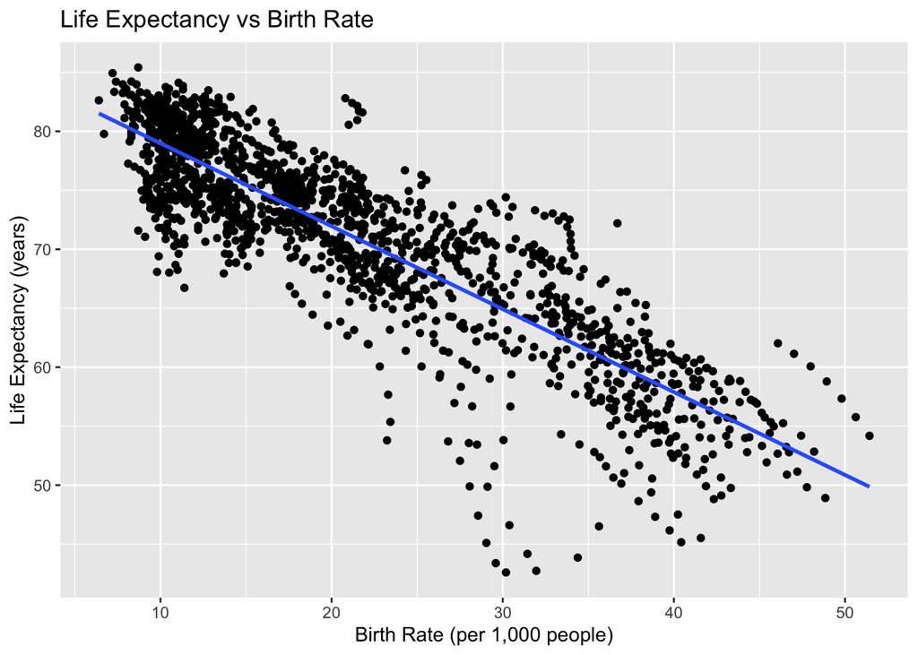

```r
p1 <- ggplot(model_vars, aes(
  x = `Birth rate, crude (per 1,000 people)`,
  y = `Life expectancy at birth, total (years)`
)) +
  geom_point() +
  geom_smooth(method = "lm", se = FALSE) +
  labs(
    title = "Life Expectancy vs Birth Rate",
    x = "Birth Rate (per 1,000 people)",
    y = "Life Expectancy (years)"
  )
p1
```

This plot shows a strong linear negative correlation between life expectancy and birth rate.

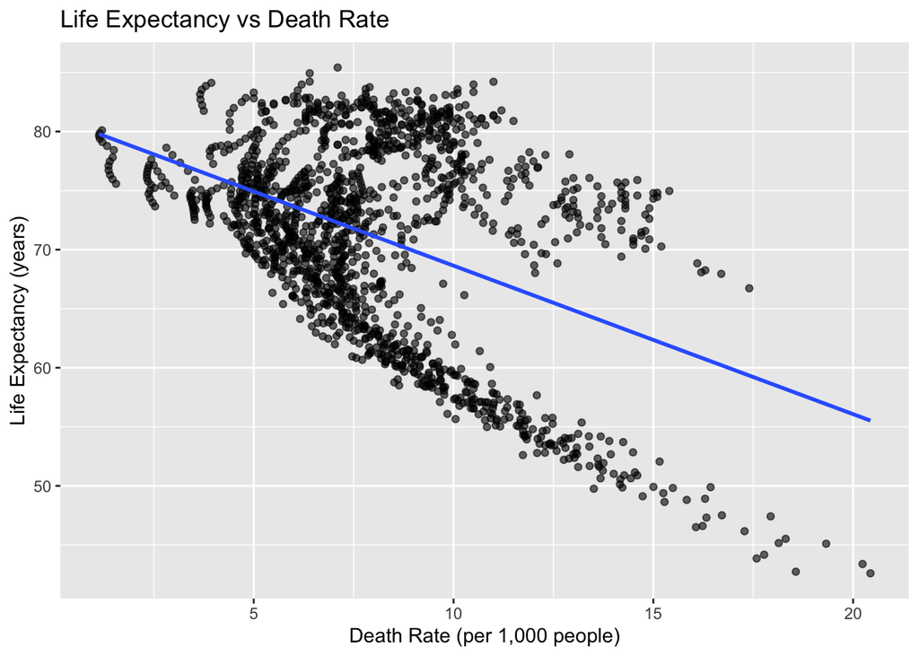

```r
p2 <- ggplot(model_vars, aes(
  x = `Death rate, crude (per 1,000 people)`,
  y = `Life expectancy at birth, total (years)`
)) +
  geom_point(alpha = 0.6) +
  geom_smooth(method = "lm", se = FALSE) +
  labs(
    title = "Life Expectancy vs Death Rate",
    x = "Death Rate (per 1,000 people)",
    y = "Life Expectancy (years)"
  )
p2
```

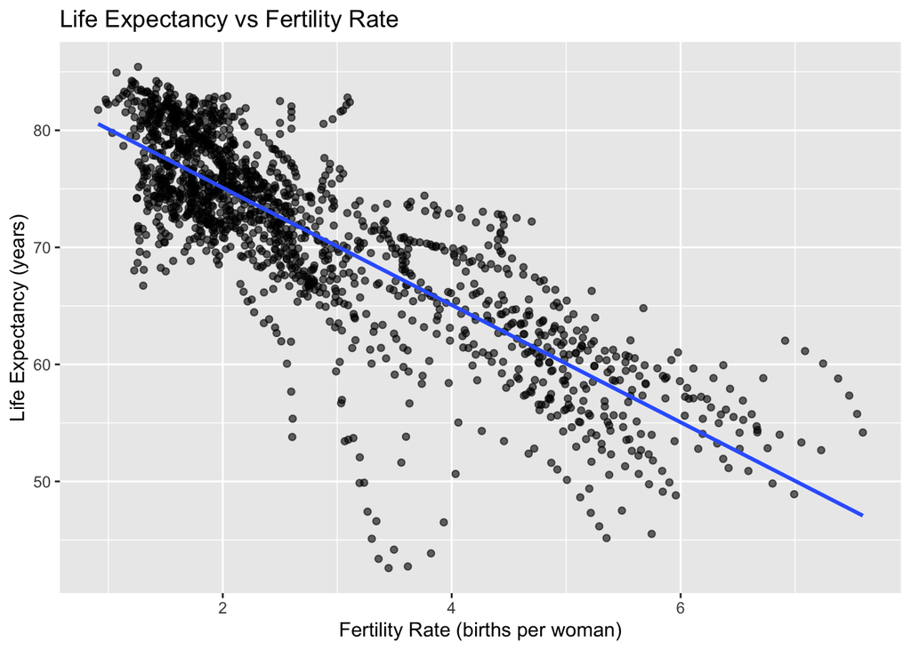

```r
p3 <- ggplot(model_vars, aes(
  x = `Fertility rate, total (births per woman)`,
  y = `Life expectancy at birth, total (years)`
)) +
  geom_point(alpha = 0.6) +
  geom_smooth(method = "lm", se = FALSE) +
  labs(
    title = "Life Expectancy vs Fertility Rate",
    x = "Fertility Rate (births per woman)",
    y = "Life Expectancy (years)"
  )
p3
```

This plot shows a strong negative correlation between life expectancy and fertility rate.

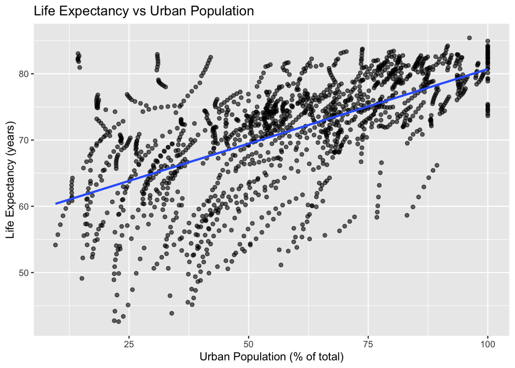

```r
p4 <- ggplot(model_vars, aes(
  x = `Urban population (% of total population)`,
  y = `Life expectancy at birth, total (years)`
)) +
  geom_point(alpha = 0.6) +
  geom_smooth(method = "lm", se = FALSE) +
  labs(
    title = "Life Expectancy vs Urban Population",
    x = "Urban Population (% of total)",
    y = "Life Expectancy (years)"
  )
p4
```

This plot shows a moderately strong positive linear correlation between life expectancy and urban population.

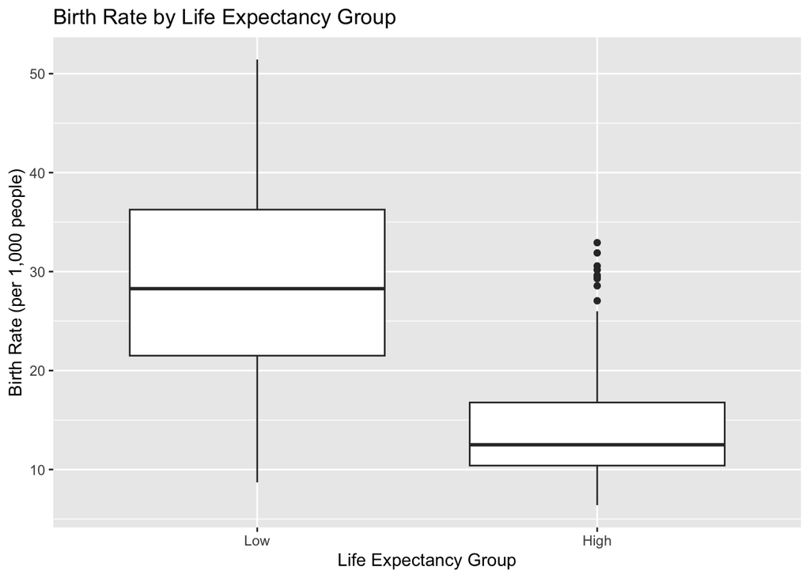

```r
p5 <- ggplot(model_vars, aes(
  x = high_lifeexp,
  y = `Birth rate, crude (per 1,000 people)`
)) +
  geom_boxplot() +
  labs(
    title = "Birth Rate by Life Expectancy Group",
    x = "Life Expectancy Group",
    y = "Birth Rate (per 1,000 people)"
  )
p5
```

This plot shows that most countries with low life expectancy will have higher birth rates than most countries with high life expectancy. You can also see that countries with low life expectancy have a higher range while the countries with high life expectancy are more concentrated besides a few outliers.

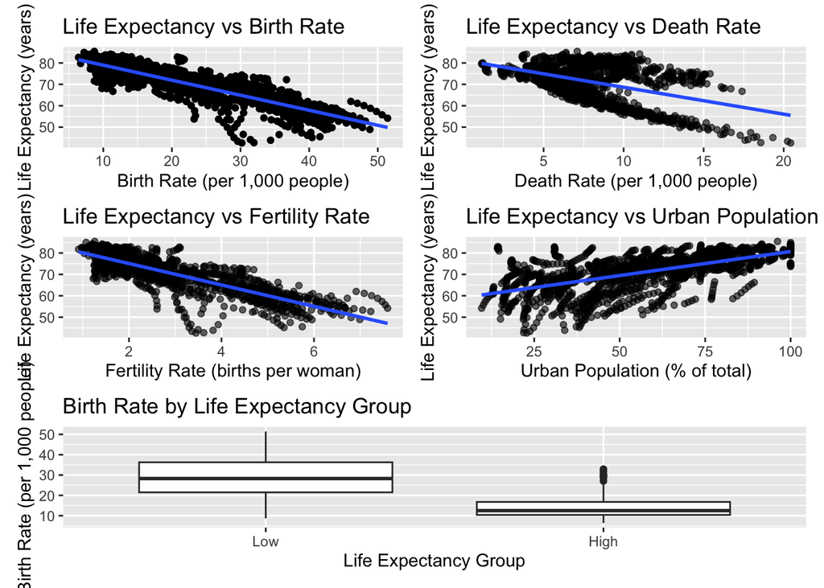

```r
(p1 + p2) / (p3 + p4) / p5
```

# Predictive Modeling

## Logistic Regression Model

```r
life_model <- glm(
  high_lifeexp ~
    `Birth rate, crude (per 1,000 people)` +
    `Death rate, crude (per 1,000 people)` +
    `Fertility rate, total (births per woman)` +
    `Urban population (% of total population)`,
  data = model_vars,
  family = binomial
)

summary(life_model)
```

```
##
## Call:
## glm(formula = high_lifeexp ~ `Birth rate, crude (per 1,000 people)` +
##     `Death rate, crude (per 1,000 people)` + `Fertility rate, total (births per woman)` +
##     `Urban population (% of total population)`, family = binomial,
##     data = model_vars)
##
## Coefficients:
##                                             Estimate Std. Error z value
## (Intercept)                                12.777103   0.979961  13.038
## `Birth rate, crude (per 1,000 people)`     -1.034343   0.083704 -12.357
## `Death rate, crude (per 1,000 people)`     -0.826771   0.061200 -13.509
## `Fertility rate, total (births per woman)`  4.391808   0.562549   7.807
## `Urban population (% of total population)`  0.040944   0.005975   6.853
##                                            Pr(>|z|)
## (Intercept)                                 < 2e-16 ***
## `Birth rate, crude (per 1,000 people)`      < 2e-16 ***
## `Death rate, crude (per 1,000 people)`      < 2e-16 ***
## `Fertility rate, total (births per woman)` 5.86e-15 ***
## `Urban population (% of total population)` 7.25e-12 ***
## ---
## Signif. codes:  0 '***' 0.001 '**' 0.01 '*' 0.05 '.' 0.1 ' ' 1
##
## (Dispersion parameter for binomial family taken to be 1)
##
##     Null deviance: 2147.4  on 1548  degrees of freedom
## Residual deviance:  659.4  on 1544  degrees of freedom
## AIC: 669.4
##
## Number of Fisher Scoring iterations: 7
```

```r
logit_full_prob <- predict(life_model, type = "response")
logit_full_pred <- ifelse(logit_full_prob >= 0.5, "High", "Low")
logit_full_pred <- factor(logit_full_pred, levels = c("Low", "High"))

logit_full_accuracy <- mean(logit_full_pred == model_vars$high_lifeexp)
logit_full_accuracy
```

```
## [1] 0.9089735
```

```r
set.seed(123)

logit_cv <- train(
  high_lifeexp ~
    `Birth rate, crude (per 1,000 people)` +
    `Death rate, crude (per 1,000 people)` +
    `Fertility rate, total (births per woman)` +
    `Urban population (% of total population)`,
  data = model_vars,
  method = "glm",
  family = binomial,
  trControl = trainControl(
    method = "cv",
    number = 5
  ),
  metric = "Accuracy"
)

logit_cv
```

```
## Generalized Linear Model
##
## 1549 samples
##    4 predictor
##    2 classes: 'Low', 'High'
##
## No pre-processing
## Resampling: Cross-Validated (5 fold)
## Summary of sample sizes: 1240, 1239, 1239, 1239, 1239
## Resampling results:
##
##   Accuracy   Kappa
##   0.9031632  0.8063211
```

```r
logit_cv_accuracy <- logit_cv$results$Accuracy[1]
logit_cv_accuracy
```

```
## [1] 0.9031632
```

## Random Forest Tree Model

```r
rf_X <- model_vars %>%
  dplyr::select(
    `Birth rate, crude (per 1,000 people)`,
    `Death rate, crude (per 1,000 people)`,
    `Fertility rate, total (births per woman)`,
    `Urban population (% of total population)`
  )

rf_y <- model_vars$high_lifeexp

set.seed(123)

rf_model <- randomForest(
  x = rf_X,
  y = rf_y,
  ntree = 500,
  importance = TRUE
)

rf_model
```

```
##
## Call:
##  randomForest(x = rf_X, y = rf_y, ntree = 500, importance = TRUE)
##                Type of random forest: classification
##                      Number of trees: 500
## No. of variables tried at each split: 2
##
##         OOB estimate of  error rate: 4.58%
## Confusion matrix:
##      Low High class.error
## Low  726   48  0.06201550
## High  23  752  0.02967742
```

```r
rf_accuracy <- 1 - rf_model$err.rate[rf_model$ntree, "OOB"]
rf_accuracy
```

```
##      OOB
## 0.954164
```

```r
set.seed(123)

rf_cv <- train(
  high_lifeexp ~
    `Birth rate, crude (per 1,000 people)` +
    `Death rate, crude (per 1,000 people)` +
    `Fertility rate, total (births per woman)` +
    `Urban population (% of total population)`,
  data = model_vars,
  method = "rf",
  trControl = trainControl(
    method = "cv",
    number = 5
  ),
  metric = "Accuracy",
  tuneLength = 3
)

rf_cv
```

```
## Random Forest
##
## 1549 samples
##    4 predictor
##    2 classes: 'Low', 'High'
##
## No pre-processing
## Resampling: Cross-Validated (5 fold)
## Summary of sample sizes: 1240, 1239, 1239, 1239, 1239
## Resampling results across tuning parameters:
##
##   mtry  Accuracy   Kappa
##   2     0.9464119  0.8928211
##   3     0.9477044  0.8954046
##   4     0.9477064  0.8954094
##
## Accuracy was used to select the optimal model using the largest value.
## The final value used for the model was mtry = 4.
```

```r
rf_cv_accuracy <- max(rf_cv$results$Accuracy)
rf_cv_accuracy
```

```
## [1] 0.9477064
```

## KNN model

```r
knn_X <- model_vars %>%
  dplyr::select(
    `Birth rate, crude (per 1,000 people)`,
    `Death rate, crude (per 1,000 people)`,
    `Fertility rate, total (births per woman)`,
    `Urban population (% of total population)`
  )

knn_X_scaled <- scale(knn_X)

knn_y <- model_vars$high_lifeexp

set.seed(123)

train_index <- sample(1:nrow(knn_X_scaled), 0.8 * nrow(knn_X_scaled))

X_train <- knn_X_scaled[train_index, ]
X_test  <- knn_X_scaled[-train_index, ]

y_train <- knn_y[train_index]
y_test  <- knn_y[-train_index]

knn_pred <- knn(
  train = X_train,
  test  = X_test,
  cl    = y_train,
  k     = 7
)

knn_table <- table(
  Actual = y_test,
  Predicted = knn_pred
)

knn_table
```

```
##       Predicted
## Actual Low High
##   Low  138   19
##   High  10  143
```

```r
knn_accuracy <- mean(knn_pred == y_test)
knn_accuracy
```

```
## [1] 0.9064516
```

```r
set.seed(123)

knn_cv <- train(
  high_lifeexp ~
    `Birth rate, crude (per 1,000 people)` +
    `Death rate, crude (per 1,000 people)` +
    `Fertility rate, total (births per woman)` +
    `Urban population (% of total population)`,
  data = model_vars,
  method = "knn",
  trControl = trainControl(
    method = "cv",
    number = 5
  ),
  preProcess = c("center", "scale"),
  tuneLength = 10,
  metric = "Accuracy"
)

knn_cv
```

```
## k-Nearest Neighbors
##
## 1549 samples
##    4 predictor
##    2 classes: 'Low', 'High'
##
## Pre-processing: centered (4), scaled (4)
## Resampling: Cross-Validated (5 fold)
## Summary of sample sizes: 1240, 1239, 1239, 1239, 1239
## Resampling results across tuning parameters:
##
##   k   Accuracy   Kappa
##    5  0.9438271  0.8876500
##    7  0.9373692  0.8747317
##    9  0.9244639  0.8489214
##   11  0.9128469  0.8256867
##   13  0.9044556  0.8088990
##   15  0.9070362  0.8140587
##   17  0.9076835  0.8153529
##   19  0.9083265  0.8166378
##   21  0.9057438  0.8114726
##   23  0.9012256  0.8024365
##
## Accuracy was used to select the optimal model using the largest value.
## The final value used for the model was k = 5.
```

```r
knn_cv_accuracy <- max(knn_cv$results$Accuracy)
knn_cv_accuracy
```

```
## [1] 0.9438271
```

## Small Logistic Model

```r
logit_small <- glm(
  high_lifeexp ~
    `Birth rate, crude (per 1,000 people)` +
    `Urban population (% of total population)`,
  data = model_vars,
  family = binomial
)

summary(logit_small)
```

```
##
## Call:
## glm(formula = high_lifeexp ~ `Birth rate, crude (per 1,000 people)` +
##     `Urban population (% of total population)`, family = binomial,
##     data = model_vars)
##
## Coefficients:
##                                             Estimate Std. Error z value
## (Intercept)                                 2.724244   0.383929   7.096
## `Birth rate, crude (per 1,000 people)`     -0.259797   0.015131 -17.170
## `Urban population (% of total population)`  0.039283   0.004254   9.235
##                                            Pr(>|z|)
## (Intercept)                                1.29e-12 ***
## `Birth rate, crude (per 1,000 people)`      < 2e-16 ***
## `Urban population (% of total population)`  < 2e-16 ***
## ---
## Signif. codes:  0 '***' 0.001 '**' 0.01 '*' 0.05 '.' 0.1 ' ' 1
##
## (Dispersion parameter for binomial family taken to be 1)
##
##     Null deviance: 2147.37  on 1548  degrees of freedom
## Residual deviance:  981.94  on 1546  degrees of freedom
## AIC: 987.94
##
## Number of Fisher Scoring iterations: 6
```

```r
logit_small_prob <- predict(logit_small, type = "response")

logit_small_pred <- ifelse(logit_small_prob >= 0.5, "High", "Low")
logit_small_pred <- factor(logit_small_pred, levels = c("Low", "High"))

logit_small_table <- table(
  Actual = model_vars$high_lifeexp,
  Predicted = logit_small_pred
)
logit_small_table
```

```
##       Predicted
## Actual Low High
##   Low  649  125
##   High  90  685
```

```r
logit_small_accuracy <- mean(logit_small_pred == model_vars$high_lifeexp)
logit_small_accuracy
```

```
## [1] 0.8612008
```

```r
set.seed(123)

logit_small_cv <- train(
  high_lifeexp ~
    `Birth rate, crude (per 1,000 people)` +
    `Urban population (% of total population)`,
  data = model_vars,
  method = "glm",
  family = binomial,
  trControl = trainControl(
    method = "cv",
    number = 5
  ),
  metric = "Accuracy"
)

logit_small_cv
```

```
## Generalized Linear Model
##
## 1549 samples
##    2 predictor
##    2 classes: 'Low', 'High'
##
## No pre-processing
## Resampling: Cross-Validated (5 fold)
## Summary of sample sizes: 1240, 1239, 1239, 1239, 1239
## Resampling results:
##
##   Accuracy   Kappa
##   0.8605429  0.7210678
```

```r
logit_small_cv_accuracy <- max(logit_small_cv$results$Accuracy)
logit_small_cv_accuracy
```

```
## [1] 0.8605429
```

## Decision Tree Model

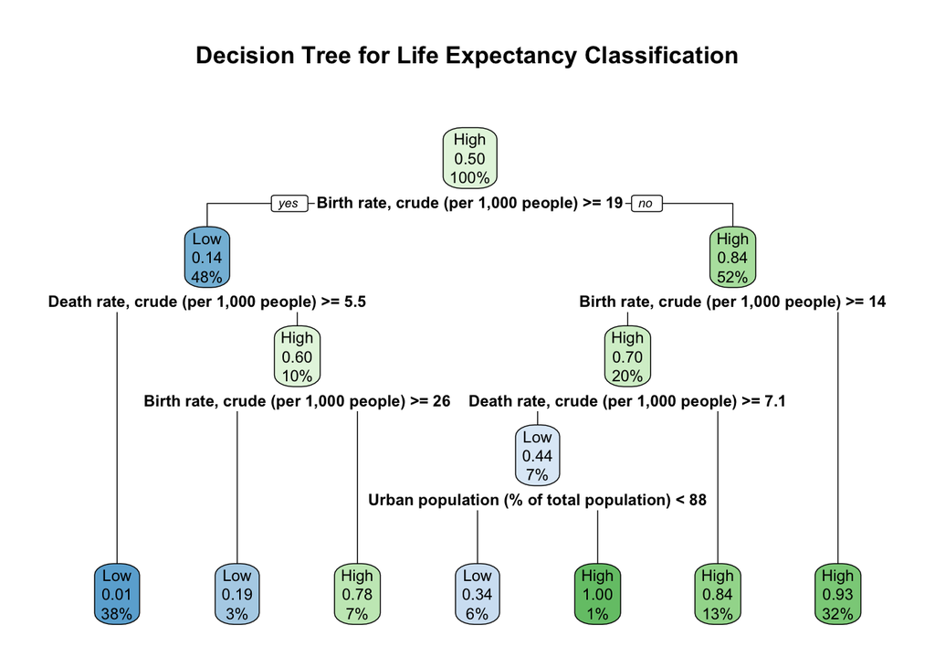

```r
tree_model <- rpart(
  high_lifeexp ~
    `Birth rate, crude (per 1,000 people)` +
    `Death rate, crude (per 1,000 people)` +
    `Fertility rate, total (births per woman)` +
    `Urban population (% of total population)`,
  data = model_vars,
  method = "class"
)

rpart.plot(tree_model, main = "Decision Tree for Life Expectancy Classification")
```

```r
tree_pred <- predict(tree_model, type = "class")

tree_table <- table(
  Actual = model_vars$high_lifeexp,
  Predicted = tree_pred
)
tree_table
```

```
##       Predicted
## Actual Low High
##   Low  684   90
##   High  47  728
```

```r
tree_accuracy <- mean(tree_pred == model_vars$high_lifeexp)
tree_accuracy
```

```
## [1] 0.9115558
```

```r
set.seed(123)

tree_data <- model_vars %>%
  dplyr::select(
    high_lifeexp,
    birth = `Birth rate, crude (per 1,000 people)`,
    death = `Death rate, crude (per 1,000 people)`,
    fertility = `Fertility rate, total (births per woman)`,
    urban = `Urban population (% of total population)`
  )

tree_cv <- train(
  high_lifeexp ~ birth + death + fertility + urban,
  data = tree_data,
  method = "rpart",
  trControl = trainControl(
    method = "cv",
    number = 5
  ),
  metric = "Accuracy"
)

tree_cv
```

```
## CART
##
## 1549 samples
##    4 predictor
##    2 classes: 'Low', 'High'
##
## No pre-processing
## Resampling: Cross-Validated (5 fold)
## Summary of sample sizes: 1240, 1239, 1239, 1239, 1239
## Resampling results across tuning parameters:
##
##   cp          Accuracy   Kappa
##   0.03875969  0.8528114  0.7055744
##   0.04134367  0.8463597  0.6926711
##   0.70542636  0.6308654  0.2617129
##
## Accuracy was used to select the optimal model using the largest value.
## The final value used for the model was cp = 0.03875969.
```

```r
tree_cv_accuracy <- max(tree_cv$results$Accuracy)
tree_cv_accuracy
```

```
## [1] 0.8528114
```

## Model Comparison

```r
comparison <- tibble(
  Model = c(
    "Logistic (Full)",
    "Random Forest",
    "kNN",
    "Logistic (Subset)",
    "Decision Tree"
  ),
  Accuracy = c(
    logit_cv_accuracy,
    rf_cv_accuracy,
    knn_cv_accuracy,
    logit_small_cv_accuracy,
    tree_cv_accuracy
  )
)

comparison
```

```
## # A tibble: 5 × 2
##   Model             Accuracy
##   <chr>                <dbl>
## 1 Logistic (Full)      0.903
## 2 Random Forest        0.948
## 3 kNN                  0.944
## 4 Logistic (Subset)    0.861
## 5 Decision Tree        0.853
```

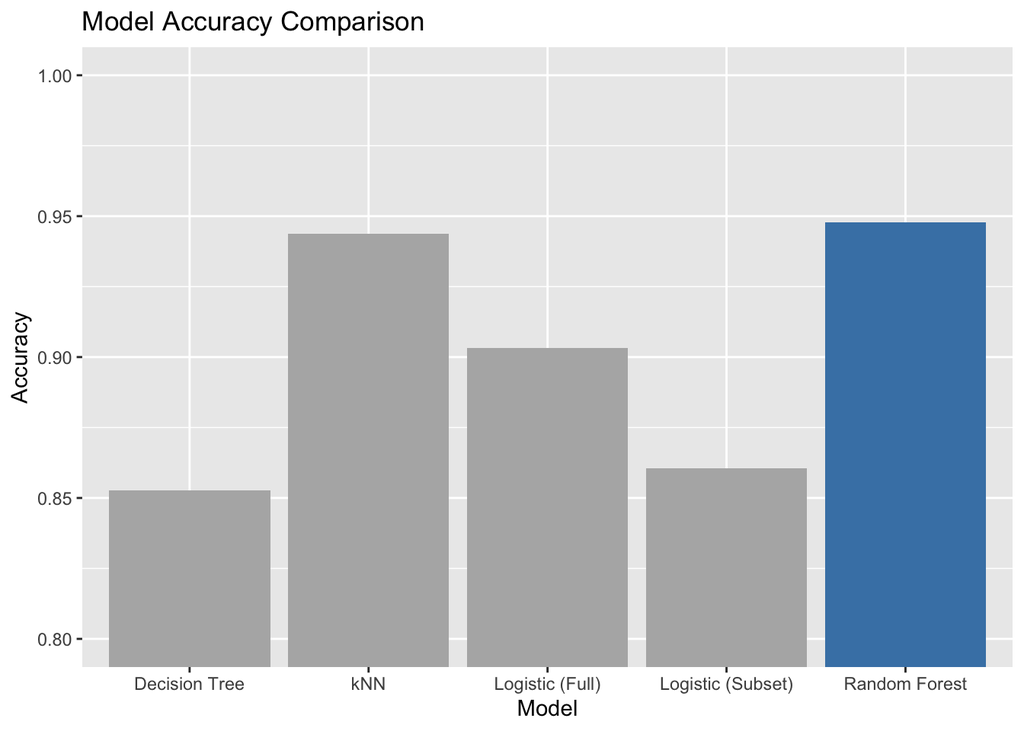

```r
accuracy_plot <- ggplot(comparison, aes(x = Model, y = Accuracy, fill = (Model == "Random Forest"))) +
  geom_col() +
  scale_fill_manual(values = c("grey70", "steelblue")) +
  coord_cartesian(ylim = c(0.8, 1)) +
  labs(
    title = "Model Accuracy Comparison",
    x = "Model",
    y = "Accuracy"
  ) +
  theme(legend.position = "none")

accuracy_plot
```

# Model Comparison Results

The random forest model was the best performing model narrowly beating the KNN model because of its ability to predict with the highest accuracy. One limitation this model has is that it is harder to interpret, making it more difficult to explain the contributions of each predictor.

# Implications of the Results

These results show us that health indicators like birth rate, death rate, fertility rate, and urban population percentage are strong predictors of whether a country will have a high or low life expectancy. This could be useful for figuring out which countries are at risk of having their life expectancy fall.